# TAE - Unit 1 - Lecture

GT

12 avril 2016

## Unit 1 - Lecture

### Getting started with R

R can be used as a basic calculator.

```r
8*6
```

```
## [1] 48
```

```r
2^16
```

```
## [1] 65536
```

R works in terms of functions and variables.

A function can take in several arguments, or input and returns an output value.

```r
sqrt(2)
```

```
## [1] 1.414214
```

```r
abs(-65)
```

```
## [1] 65
```

To save the output of a function, it’s possible to saving it to a variable

```r
SquareRoot2 = sqrt(2)
SquareRoot2
```

```
## [1] 1.414214
```

Don’t use spaces in variable names, don’t start variable names with a number

It’s possible to do assignement with ‘=’ or ‘<-’

```r
HoursYear <- 365*24
HoursYear
```

```
## [1] 8760
```

List all variable created in the session

```r
ls()
```

```
## [1] "HoursYear"   "SquareRoot2"
```

### Vectors and Data Frames

A vector is a series of numbers or characters stored as the same object.

You can create a vector in R using the ‘c’ function (combine).

Create a vector of country names, then enter the life expectancies in the same order

```r
c(2, 3, 5, 8, 13)
```

```
## [1]  2  3  5  8 13
```

```r
Country = c("Brazil", "China", "India", "Switzerland", "USA")
LifeExpectancy = c(74, 76, 65, 83, 79)
Country
```

```
## [1] "Brazil"      "China"       "India"       "Switzerland" "USA"
```

```r
LifeExpectancy
```

```
## [1] 74 76 65 83 79
```

To display an element of a vector, use square brackets.

```r
Country[1] # To get the first
```

```
## [1] "Brazil"
```

```r
LifeExpectancy[3] # To get the third
```

```
## [1] 65
```

Another nice function to create vectors is the ‘seq’ function.

This give a sequence of numbers from 0 to 100 and the numbers increment of two

```r
seq(0, 100, 2)
```

```
##  [1]   0   2   4   6   8  10  12  14  16  18  20  22  24  26  28  30  32
## [18]  34  36  38  40  42  44  46  48  50  52  54  56  58  60  62  64  66
## [35]  68  70  72  74  76  78  80  82  84  86  88  90  92  94  96  98 100
```

Some algorithms require all of the data to be in a sigle object like a data frame

```r
CountryData = data.frame(Country, LifeExpectancy)
CountryData
```

```
##       Country LifeExpectancy
## 1      Brazil             74
## 2       China             76
## 3       India             65
## 4 Switzerland             83
## 5         USA             79
```

To add another variable to the data

```r
CountryData$Population=c(199000, 1390000, 1240000, 7997, 318000)
CountryData
```

```
##       Country LifeExpectancy Population
## 1      Brazil             74     199000
## 2       China             76    1390000
## 3       India             65    1240000
## 4 Switzerland             83       7997
## 5         USA             79     318000
```

To add two new observations

```r
Country = c("Australia", "Greece")
LifeExpectancy = c(82, 81)
Population = c(23050, 11125)
```

Then create a new data frame

```r
NewCountryData = data.frame(Country, LifeExpectancy, Population)
NewCountryData
```

```
##     Country LifeExpectancy Population
## 1 Australia             82      23050
## 2    Greece             81      11125
```

The rbind() function combines both data frames by stacking the rows.

```r
AllCountryData = rbind(CountryData, NewCountryData)
AllCountryData
```

```
##       Country LifeExpectancy Population
## 1      Brazil             74     199000
## 2       China             76    1390000
## 3       India             65    1240000
## 4 Switzerland             83       7997
## 5         USA             79     318000
## 6   Australia             82      23050
## 7      Greece             81      11125
```

### Loading Data Files

Read the data file WHO.csv and save it in data frame

```r
getwd()
```

```
## [1] "/home/gio/Documents/TAE/Unit1"
```

```r
WHO = read.csv("WHO.csv")
```

To look at the data, there are two useful commands: str() and summary()

str() show the structure of the data, for each variable, str() gives the name of the variable, a description of the type of the variable, followed by a first few values of the variable.

summary() for the factor variables it count the number of observations in each of the levels or categories. For each of the numerical values, it’s calculated the min, max, mean,first quartile, third quartile, median

```r
str(WHO)
```

```
## 'data.frame':    194 obs. of  13 variables:
##  $ Country                      : Factor w/ 194 levels "Afghanistan",..: 1 2 3 4 5 6 7 8 9 10 ...
##  $ Region                       : Factor w/ 6 levels "Africa","Americas",..: 3 4 1 4 1 2 2 4 6 4 ...
##  $ Population                   : int  29825 3162 38482 78 20821 89 41087 2969 23050 8464 ...
##  $ Under15                      : num  47.4 21.3 27.4 15.2 47.6 ...
##  $ Over60                       : num  3.82 14.93 7.17 22.86 3.84 ...
##  $ FertilityRate                : num  5.4 1.75 2.83 NA 6.1 2.12 2.2 1.74 1.89 1.44 ...
##  $ LifeExpectancy               : int  60 74 73 82 51 75 76 71 82 81 ...
##  $ ChildMortality               : num  98.5 16.7 20 3.2 163.5 ...
##  $ CellularSubscribers          : num  54.3 96.4 99 75.5 48.4 ...
##  $ LiteracyRate                 : num  NA NA NA NA 70.1 99 97.8 99.6 NA NA ...
##  $ GNI                          : num  1140 8820 8310 NA 5230 ...
##  $ PrimarySchoolEnrollmentMale  : num  NA NA 98.2 78.4 93.1 91.1 NA NA 96.9 NA ...
##  $ PrimarySchoolEnrollmentFemale: num  NA NA 96.4 79.4 78.2 84.5 NA NA 97.5 NA ...
```

```r
summary(WHO)
```

```
##                 Country                      Region     Population
##  Afghanistan        :  1   Africa               :46   Min.   :      1
##  Albania            :  1   Americas             :35   1st Qu.:   1696
##  Algeria            :  1   Eastern Mediterranean:22   Median :   7790
##  Andorra            :  1   Europe               :53   Mean   :  36360
##  Angola             :  1   South-East Asia      :11   3rd Qu.:  24535
##  Antigua and Barbuda:  1   Western Pacific      :27   Max.   :1390000
##  (Other)            :188
##     Under15          Over60      FertilityRate   LifeExpectancy
##  Min.   :13.12   Min.   : 0.81   Min.   :1.260   Min.   :47.00
##  1st Qu.:18.72   1st Qu.: 5.20   1st Qu.:1.835   1st Qu.:64.00
##  Median :28.65   Median : 8.53   Median :2.400   Median :72.50
##  Mean   :28.73   Mean   :11.16   Mean   :2.941   Mean   :70.01
##  3rd Qu.:37.75   3rd Qu.:16.69   3rd Qu.:3.905   3rd Qu.:76.00
##  Max.   :49.99   Max.   :31.92   Max.   :7.580   Max.   :83.00
##                                  NA's   :11
##  ChildMortality    CellularSubscribers  LiteracyRate        GNI
##  Min.   :  2.200   Min.   :  2.57      Min.   :31.10   Min.   :  340
##  1st Qu.:  8.425   1st Qu.: 63.57      1st Qu.:71.60   1st Qu.: 2335
##  Median : 18.600   Median : 97.75      Median :91.80   Median : 7870
##  Mean   : 36.149   Mean   : 93.64      Mean   :83.71   Mean   :13321
##  3rd Qu.: 55.975   3rd Qu.:120.81      3rd Qu.:97.85   3rd Qu.:17558
##  Max.   :181.600   Max.   :196.41      Max.   :99.80   Max.   :86440
##                    NA's   :10          NA's   :91      NA's   :32
##  PrimarySchoolEnrollmentMale PrimarySchoolEnrollmentFemale
##  Min.   : 37.20              Min.   : 32.50
##  1st Qu.: 87.70              1st Qu.: 87.30
##  Median : 94.70              Median : 95.10
##  Mean   : 90.85              Mean   : 89.63
##  3rd Qu.: 98.10              3rd Qu.: 97.90
##  Max.   :100.00              Max.   :100.00
##  NA's   :93                  NA's   :93
```

It’s possible to subset the data with the subset() function. The function take two arguments, the first is the data frame, the second is the criteria for which observation we want subset

```r
WHO_Europe = subset(WHO, Region == "Europe")
```

To save this new data frame to a csv file, there is the write.csv() function

```r
write.csv(WHO_Europe, "WHO_Europe.csv")
```

After the saving, it’s possible to remove the data frame from the current session

```r
ls()
```

```
##  [1] "AllCountryData" "Country"        "CountryData"    "HoursYear"
##  [5] "LifeExpectancy" "NewCountryData" "Population"     "SquareRoot2"
##  [9] "WHO"            "WHO_Europe"
```

```r
rm(WHO_Europe)
ls()
```

```
## [1] "AllCountryData" "Country"        "CountryData"    "HoursYear"
## [5] "LifeExpectancy" "NewCountryData" "Population"     "SquareRoot2"
## [9] "WHO"
```

### Summary Statistics and Scatterplot

To access a variable in a data frame, it has to be linked to the data frame it belongs to with the dollar sign. The output is a vector of the data frame WHO. It’s possible to compute some statistics about the variable like the mean or the standard deviation.

```r
WHO$Under15
```

```
##   [1] 47.42 21.33 27.42 15.20 47.58 25.96 24.42 20.34 18.95 14.51 22.25
##  [12] 21.62 20.16 30.57 18.99 15.10 16.88 34.40 42.95 28.53 35.23 16.35
##  [23] 33.75 24.56 25.75 13.53 45.66 44.20 31.23 43.08 16.37 30.17 40.07
##  [34] 48.52 21.38 17.95 28.03 42.17 42.37 30.61 23.94 41.48 14.98 16.58
##  [45] 17.16 14.56 21.98 45.11 17.66 33.72 25.96 30.53 30.29 31.25 30.62
##  [56] 38.95 43.10 15.69 43.29 28.88 16.42 18.26 38.49 45.90 17.62 13.17
##  [67] 38.59 14.60 26.96 40.80 42.46 41.55 36.77 35.35 35.72 14.62 20.71
##  [78] 29.43 29.27 23.68 40.51 21.54 27.53 14.04 27.78 13.12 34.13 25.46
##  [89] 42.37 30.10 24.90 30.21 35.61 14.57 21.64 36.75 43.06 29.45 15.13
## [100] 17.46 42.72 45.44 26.65 29.03 47.14 14.98 30.10 40.22 20.17 29.02
## [111] 35.81 18.26 27.05 19.01 27.85 45.38 25.28 36.59 30.10 35.58 17.21
## [122] 20.26 33.37 49.99 44.23 30.61 18.64 24.19 34.31 30.10 28.65 38.37
## [133] 32.78 29.18 34.53 14.91 14.92 13.28 15.25 16.52 15.05 15.45 43.56
## [144] 25.96 24.31 25.70 37.88 14.04 41.60 29.69 43.54 16.45 21.95 41.74
## [155] 16.48 15.00 14.16 40.37 47.35 29.53 42.28 15.20 25.15 41.48 27.83
## [166] 38.05 16.71 14.79 35.35 35.75 18.47 16.89 46.33 41.89 37.33 20.73
## [177] 23.22 26.00 28.65 30.61 48.54 14.18 14.41 17.54 44.85 19.63 22.05
## [188] 28.90 37.37 28.84 22.87 40.72 46.73 40.24
```

```r
mean(WHO$Under15)
```

```
## [1] 28.73242
```

```r
sd(WHO$Under15)
```

```
## [1] 10.53457
```

It’s possible to get the statistical summary of just one variable

```r
summary(WHO$Under15)
```

```
##    Min. 1st Qu.  Median    Mean 3rd Qu.    Max.
##   13.12   18.72   28.65   28.73   37.75   49.99
```

This output tells us that there’s a country with only 13% of the population under 15.

It’s possible to see which country it is using the which.min() function. The returned number is the row number of the observation and it’s easy to see which country is in this row.

```r
which.min(WHO$Under15)
```

```
## [1] 86
```

```r
WHO$Country[86]
```

```
## [1] Japan
## 194 Levels: Afghanistan Albania Algeria Andorra ... Zimbabwe
```

Example, to see the country that has the maximum percentage of the population under 15.

```r
WHO$Country[which.max(WHO$Under15)]
```

```
## [1] Niger
## 194 Levels: Afghanistan Albania Algeria Andorra ... Zimbabwe
```

To create a scatter plot of GNI vs fertility rate using the plot() function

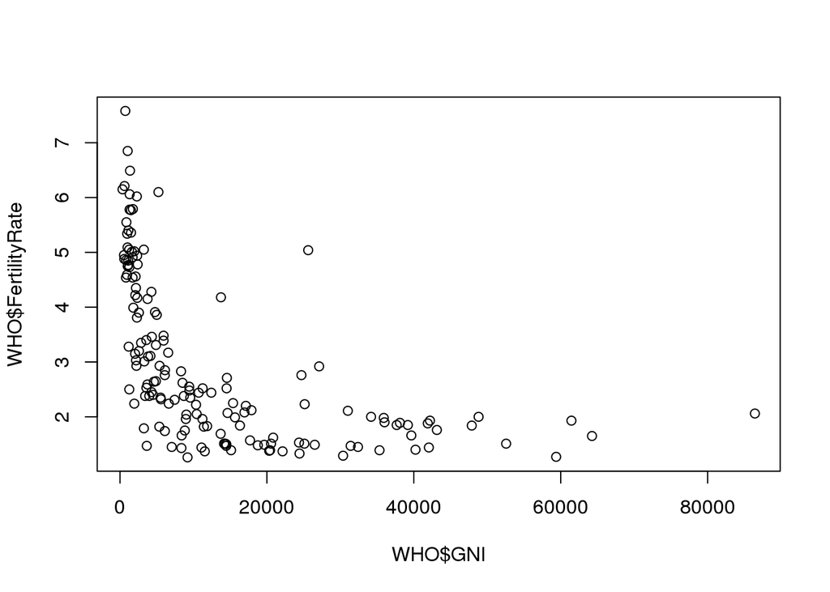

```r
plot(WHO$GNI, WHO$FertilityRate)
```

There are few countries for which both the GNI and the fertility rate are high, and using the nrow() function to see how many rows are in the subset.

```r
Outliers = subset(WHO, GNI > 10000 & FertilityRate > 2.5)
nrow(Outliers)
```

```
## [1] 7
```

There’s an easy way to extract a few variables from a dataset

```r
Outliers[c("Country", "GNI", "FertilityRate")]
```

```
##               Country   GNI FertilityRate
## 23           Botswana 14550          2.71
## 56  Equatorial Guinea 25620          5.04
## 63              Gabon 13740          4.18
## 83             Israel 27110          2.92
## 88         Kazakhstan 11250          2.52
## 131            Panama 14510          2.52
## 150      Saudi Arabia 24700          2.76
```

### Plots and Summary Tables

In addition to scatter plots, there are several other types of plots in R.

Create an histogram with the hist() function. A histogram is useful for understanding the distribution of a variable

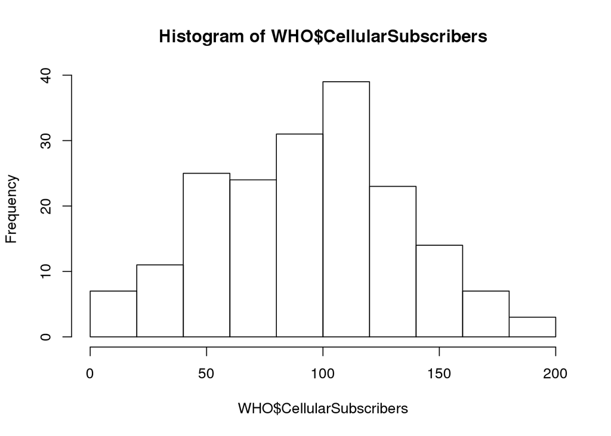

```r
hist(WHO$CellularSubscribers)
```

It’s easy to create a boxplot of Life expecancy sorted by region. A box plot is useful for understanding the statistical range of a variable. The box for each region shows the range between the first and third quartiles with the middle line marking the median value. The dashed lines at the top and bottom of the box show the range from

- the minimum: first quartile minus 1.5*IQR (inter-quartile range) and
- the maximum: third qurtile plus 1.5*IQR (inter-quartile range)

excluding the outliers

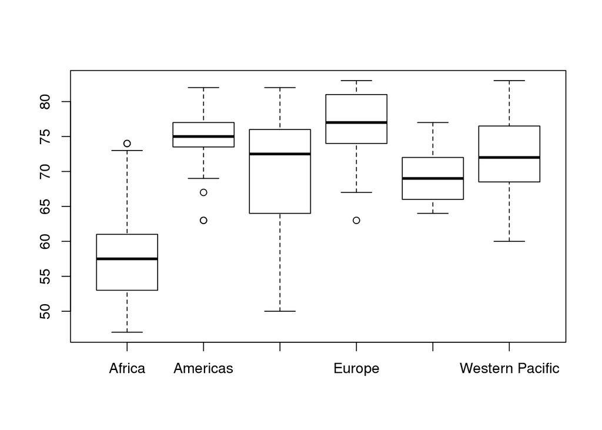

```r
boxplot(WHO$LifeExpectancy ~ WHO$Region)
```

In order to have nice labels it’s necessary to add a few arguments

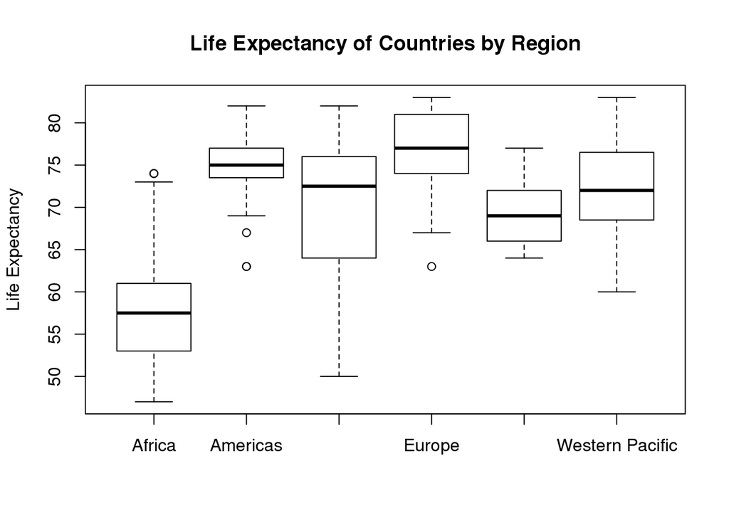

```r
boxplot(WHO$LifeExpectancy ~ WHO$Region, ylab = "Life Expectancy", main = "Life Expectancy of Countries by Region")
```

Look at the data using some summary tables This counts the number of obs in each category. Table works well for variables with only a few possible values.

```r
table(WHO$Region)
```

```
##
##                Africa              Americas Eastern Mediterranean
##                    46                    35                    22
##                Europe       South-East Asia       Western Pacific
##                    53                    11                    27
```

In order to see some nice information about numerical variables by using tapply() function. This split the obs by region and then computes the mean of the variable Over60. Tapply splits the data by the second argument given and then apply the third argument function

```r
tapply(WHO$Over60, WHO$Region, mean)
```

```
##                Africa              Americas Eastern Mediterranean
##              5.220652             10.943714              5.620000
##                Europe       South-East Asia       Western Pacific
##             19.774906              8.769091             10.162963
```

```r
# Another example
tapply(WHO$LiteracyRate, WHO$Region, min)
```

```
##                Africa              Americas Eastern Mediterranean
##                    NA                    NA                    NA
##                Europe       South-East Asia       Western Pacific
##                    NA                    NA                    NA
```

```r
tapply(WHO$LiteracyRate, WHO$Region, min, na.rm=TRUE)
```

```
##                Africa              Americas Eastern Mediterranean
##                  31.1                  75.2                  63.9
##                Europe       South-East Asia       Western Pacific
##                  95.2                  56.8                  60.6
```

The ‘na.rm’ option removes all missing value before doing the computation